# Milestone Report

# Tokenize Data into 2-grams and 3-grams

```r
options( java.parameters = "-Xmx4g" )
library(RWeka)
library("tm")
```

```r
#twitter
twitter_strings <- readLines(con =  file("en_US.twitter.txt", "r", blocking = FALSE), n = 10000)
two_gram_twitter <- NGramTokenizer(twitter_strings, Weka_control(min = 2, max = 2))
two_gram_twitter <- tolower(two_gram_twitter)
three_gram_twitter <- NGramTokenizer(twitter_strings, Weka_control(min = 3, max = 3))
three_gram_twitter <- tolower(three_gram_twitter)

#blogs
blogs_strings <- readLines(con =  file("en_US.blogs.txt", "r", blocking = FALSE), n = 10000)
two_gram_blogs <- NGramTokenizer(blogs_strings, Weka_control(min = 2, max = 2))
two_gram_blogs <- tolower(two_gram_blogs)
three_gram_blogs <- NGramTokenizer(blogs_strings, Weka_control(min = 3, max = 3))
three_gram_blogs <- tolower(three_gram_blogs)

#news
news_strings <- readLines(con =  file("en_US.news.txt", "r", blocking = FALSE), n = 10000)
two_gram_news <- NGramTokenizer(news_strings, Weka_control(min = 2, max = 2))
two_gram_news <- tolower(two_gram_news)
three_gram_news <- NGramTokenizer(news_strings, Weka_control(min = 3, max = 3))
three_gram_news <- tolower(three_gram_news)

#total
total_two_gram <- c(two_gram_twitter, two_gram_blogs, two_gram_news)
total_two_gram <- tolower(total_two_gram)
total_three_gram <- c(three_gram_twitter, three_gram_blogs, three_gram_news)
total_three_gram <- tolower(total_two_gram)
```

## N-Gram Summary

This section displays the basic descriptive statistics for 2-gram and 3-gram version of the three files and combination of all three.

### Twitter

```r
# Top 10 two-gram terms
two_gram_twitter_sort <- sort(table(two_gram_twitter), decreasing = TRUE)
two_gram_twitter_sort[1:10]
```

```
## two_gram_twitter
##        i m       it s     in the      don t    for the     of the
##        520        354        325        321        314        245
##      to be      can t     on the thanks for
##        220        197        195        193
```

```r
# Top 10 three-gram terms
three_gram_twitter_sort <- sort(table(three_gram_twitter), decreasing = TRUE)
three_gram_twitter_sort[1:10]
```

```
## three_gram_twitter
##     thanks for the            i don t            i can t
##                107                 94                 67
##         can t wait         i love you      thank you for
##                 54                 42                 41
##            i m not        going to be          i want to
##                 37                 36                 35
## looking forward to
##                 35
```

### Blogs

```r
# Top 10 two-gram terms
two_gram_blogs_sort <- sort(table(two_gram_blogs), decreasing = TRUE)
two_gram_blogs_sort[1:10]
```

```
## two_gram_blogs
##  of the  in the  to the  on the   to be and the for the   and i   i was
##    2045    1660     982     796     759     661     630     609     542
##  it was
##     525
```

```r
# Top 10 three-gram terms
three_gram_blogs_sort <- sort(table(three_gram_blogs), decreasing = TRUE)
three_gram_blogs_sort[1:10]
```

```
## three_gram_blogs
##  one of the    a lot of     i don t    i didn t     to be a  as well as
##         169         151         143          80          78          70
## some of the     i can t  out of the  the end of
##          70          67          66          66
```

### News

```r
# Top 10 two-gram terms
two_gram_news_sort <- sort(table(two_gram_news), decreasing = TRUE)
two_gram_news_sort[1:10]
```

```
## two_gram_news
##  of the  in the  to the for the  on the    it s  at the and the    in a
##    1805    1735     817     714     699     608     570     495     485
##   to be
##     471
```

```r
# Top 10 three-gram terms
three_gram_news_sort <- sort(table(three_gram_news), decreasing = TRUE)
three_gram_news_sort[1:10]
```

```
## three_gram_news
##       one of the          the u s         a lot of          i don t
##              139              131              108               94
##           it s a       as well as         it s not according to the
##               93               74               73               62
##       the end of      going to be
##               56               54
```

### Total

```r
# Top 10 two-gram terms
two_gram_total_sort <- sort(table(total_two_gram), decreasing = TRUE)
two_gram_total_sort[1:10]
```

```
## total_two_gram
##  of the  in the  to the  on the for the   to be    it s  at the and the
##    4095    3720    1976    1690    1658    1450    1442    1222    1219
##     i m
##    1176
```

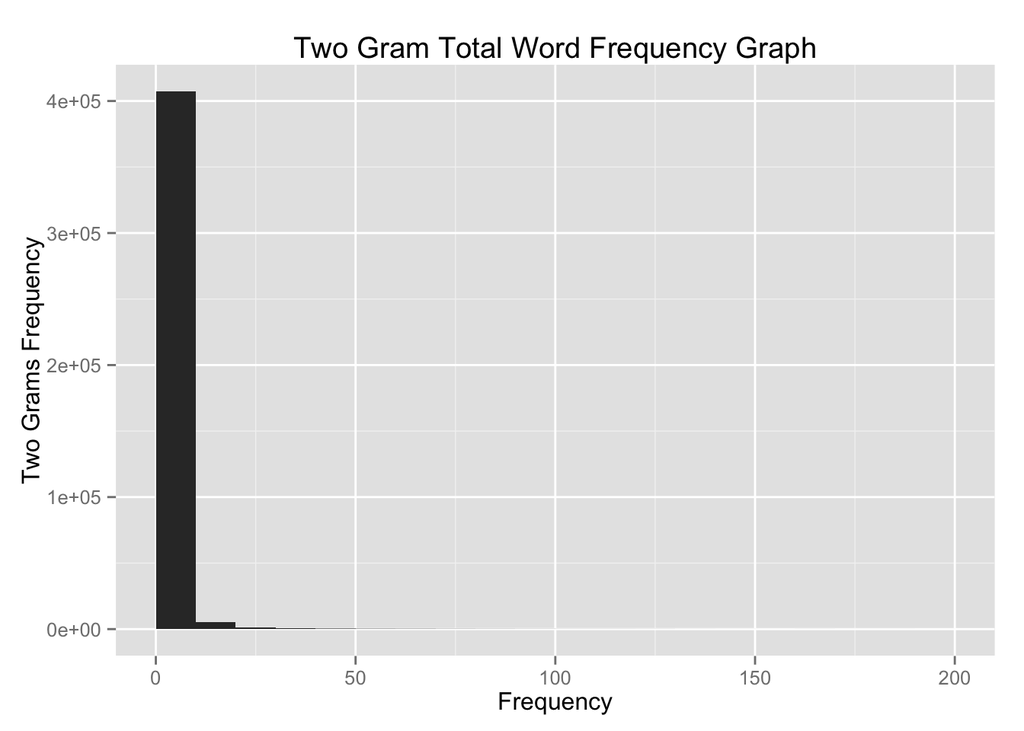

```r
# Two-gram distribution graph
plot_two_gram_total <- qplot(two_gram_total_sort,binwidth = 10) + ggtitle("Two Gram Total Word Frequency Graph") + xlab("Frequency") + ylab("Two Grams Frequency") + scale_x_continuous(limits=c(0, 200))
plot_two_gram_total
```

```r
# Top 10 three-gram terms
three_gram_total_sort <- sort(table(total_three_gram), decreasing = TRUE)
three_gram_total_sort[1:10]
```

[output not shown]

[figure not shown]

```r
# Three-gram distribution graph
plot_three_gram_total <- qplot(three_gram_total_sort,binwidth = 10) + ggtitle("Three Gram Total Word Frequency Graph") + xlab("Frequency") + ylab("Three Grams Frequency") + scale_x_continuous(limits=c(0, 200))
plot_three_gram_total
```

## Insights

As we can see, for almost all graphs, most of the words are concentrated in the low frequency area occur less than 10 times in the dataset. There are only few words and n-grams that are very frequently used and can reach a extremly high frequency.

## Next Step

To build my prediction model, I plan first to constuct a 2-gram model.The first step of the 2-gram model is to calculate the probability of second word’s occurance in the 2-gram given the first word. This operation is going to be done on all 2-gram of a specific sentence to calculate the probability of that sentence from occuring. For example, for “I want to eat”, the sentence is going to be borken down to “i”, “i want”, “want to”, “to eat”, “eat”, the probability of all of these terms are going to be calculated and the product of all these terms are going to return the probability of this sentence occuring.

With the same principle, I am going to also construct a 3-gram model that is able to calculate the probably of any given sentences.